# Predicting Cardiovascular Disease

November 25, 2019

```r
# some of common options (and the defaults) are:
# include=T, eval=T, echo=T, results='hide'/'asis',..., collapse=F, warning=T, message=T, error=T, cache=T, fig.width=6, fig.height=4, fig.dim=c(6,4) #inches, fig.align='left'/'center','right',
#knitr::opts_chunk$set(include = F)
knitr::opts_chunk$set(echo = F)
options(scientific=T, digits = 3)
# options(scipen=9, digits = 3)
# âscipenâ: integer. A penalty to be applied when deciding to print numeric values in fixed or exponential notation.  Positive values bias towards fixed and negative towards scientific notation: fixed notation will be preferred unless it is more than âscipenâ digits wider.
# use scipen=999 to prevent scientific notation at all times
```

## Chapter 1: Introduction

Cardiovascular diseases (CVD) are conditions that involve the heart and blood vessels. CVD affects the structures or function of your heart. Cardiovascular diseases can refer to a number of conditions such as coronary heart disease, cerebrovascular disease, and peripheral arterial disease. According to the World Health Organization, cardiovascular diseases are the number one cause of death globally: more people die annually from cardiovascular diseases than from any other cause. An estimated 17.9 million people died from cardiovascular diseases in 2016, representing 31% of all global deaths. Of these deaths, 85% are due to heart attack and stroke. Heart attacks and strokes are usually acute events and are mainly caused by a blockage that prevents blood from flowing to the heart or brain. The most common reason for this is a build-up of fatty deposits on the inner walls of the blood vessels that supply the heart or brain.(source)[https://www.who.int]

The Centers for Disease Control and Prevention state high blood pressure, high cholesterol, and smoking are key risk factors for heart disease. About half of Americans (47%) have at least one of these three risk factors. Several other medical conditions and lifestyle choices can also put people at a higher risk for heart disease, including poor diet, physical inactivity, and excessive alcohol use.(source)[https://www.cdc.gov/heartdisease/facts.htm]

CVD costs the US about $200 billion each year for health care services, medications, and lost productivity. Most people do not know that they have CVD until they experience chest pain or numbness in the upper body. CVD can be diagnosed earlier, and patients should be well aware of their potential heart conditions through doctors if their health data can be analyzed and run through prediction models. With the fabulously improved computer technology and software nowadays, hospitals and small doctor offices can store health data for everyone, and the data can be used to predict if someone has CVD. Diagnosing correctly has become a challenge because a wrong decision can lead to patient death and loss of reputation of the doctor office. In addition, the cost for treating heart disease is high. Therefore, Therefore, a system that can predict heart disease is essential to help reduce the cost of treatment and deaths. Knowing the possibility of getting CVD helps patients have a proper care and prevention (directed by doctors) as early as possible.

In this report, different prediction models including Logistic Regression, KNN, and Decision Tree are developed and performed on a dataset of 70,000 patient data with 11 features and 1 target. Then, the models are compared to determine the best model to predict CVD. Additionally, key factors contributing to CDV will be addressed to raise awareness.

## Chapter 2: Description of Dataset

For our second project, we have chosen a dataset that contains 70,000 records of patients data. We downloaded this dataset from (source)[https://www.kaggle.com/sulianova/cardiovascular-disease-dataset]. Following is a list of the variables contained in our dataset:

- Age
- Height
- Weight
- Gender
- Systolic blood pressure
- Diastolic blood pressure
- Cholesterol | 1: normal, 2: above normal, 3: well above normal
- Glucose | 1: normal, 2: above normal, 3: well above normal |
- Smoking
- Alcohol intake
- Physical activity
- Presence or absence of cardiovascular disease

### Importing the cardio dataset and cleaning:

```
## 'data.frame':    70000 obs. of  13 variables:
##  $ id         : int  0 1 2 3 4 8 9 12 13 14 ...
##  $ age        : int  18393 20228 18857 17623 17474 21914 22113 22584 17668 19834 ...
##  $ gender     : int  2 1 1 2 1 1 1 2 1 1 ...
##  $ height     : int  168 156 165 169 156 151 157 178 158 164 ...
##  $ weight     : num  62 85 64 82 56 67 93 95 71 68 ...
##  $ ap_hi      : int  110 140 130 150 100 120 130 130 110 110 ...
##  $ ap_lo      : int  80 90 70 100 60 80 80 90 70 60 ...
##  $ cholesterol: int  1 3 3 1 1 2 3 3 1 1 ...
##  $ gluc       : int  1 1 1 1 1 2 1 3 1 1 ...
##  $ smoke      : int  0 0 0 0 0 0 0 0 0 0 ...
##  $ alco       : int  0 0 0 0 0 0 0 0 0 0 ...
##  $ active     : int  1 1 0 1 0 0 1 1 1 0 ...
##  $ cardio     : int  0 1 1 1 0 0 0 1 0 0 ...
```

```
##        id             age            gender         height        weight
##  Min.   :    0   Min.   :10798   Min.   :1.00   Min.   : 55   Min.   : 10.0
##  1st Qu.:25007   1st Qu.:17664   1st Qu.:1.00   1st Qu.:159   1st Qu.: 65.0
##  Median :50002   Median :19703   Median :1.00   Median :165   Median : 72.0
##  Mean   :49972   Mean   :19469   Mean   :1.35   Mean   :164   Mean   : 74.2
##  3rd Qu.:74889   3rd Qu.:21327   3rd Qu.:2.00   3rd Qu.:170   3rd Qu.: 82.0
##  Max.   :99999   Max.   :23713   Max.   :2.00   Max.   :250   Max.   :200.0
##      ap_hi           ap_lo        cholesterol        gluc          smoke
##  Min.   : -150   Min.   :  -70   Min.   :1.00   Min.   :1.00   Min.   :0.000
##  1st Qu.:  120   1st Qu.:   80   1st Qu.:1.00   1st Qu.:1.00   1st Qu.:0.000
##  Median :  120   Median :   80   Median :1.00   Median :1.00   Median :0.000
##  Mean   :  129   Mean   :   97   Mean   :1.37   Mean   :1.23   Mean   :0.088
##  3rd Qu.:  140   3rd Qu.:   90   3rd Qu.:2.00   3rd Qu.:1.00   3rd Qu.:0.000
##  Max.   :16020   Max.   :11000   Max.   :3.00   Max.   :3.00   Max.   :1.000
##       alco           active          cardio
##  Min.   :0.000   Min.   :0.000   Min.   :0.0
##  1st Qu.:0.000   1st Qu.:1.000   1st Qu.:0.0
##  Median :0.000   Median :1.000   Median :0.0
##  Mean   :0.054   Mean   :0.804   Mean   :0.5
##  3rd Qu.:0.000   3rd Qu.:1.000   3rd Qu.:1.0
##  Max.   :1.000   Max.   :1.000   Max.   :1.0
```

The column id is removed from the dataset. ap_hi and ap_lo should not be negative so the negative values are removed. Also, there is an unreasonable values for ap_hi and ap_lo which are 16020 and 11000. These values are unbelievable for a blood pressure reading, so we subset the data with ap_lo and ap_lo less than 500. We also converted the unit for variable age into years.

### Correlation matrix

Correlation matrix is used here to see if there is any strong correlation between cardio and the other variables.

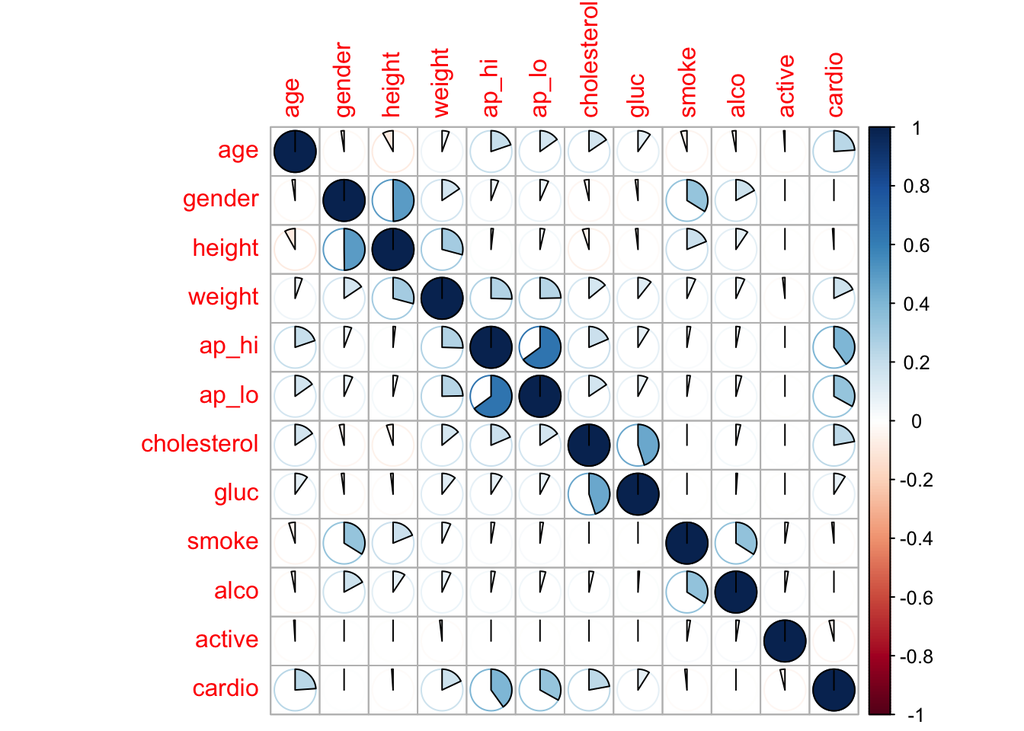

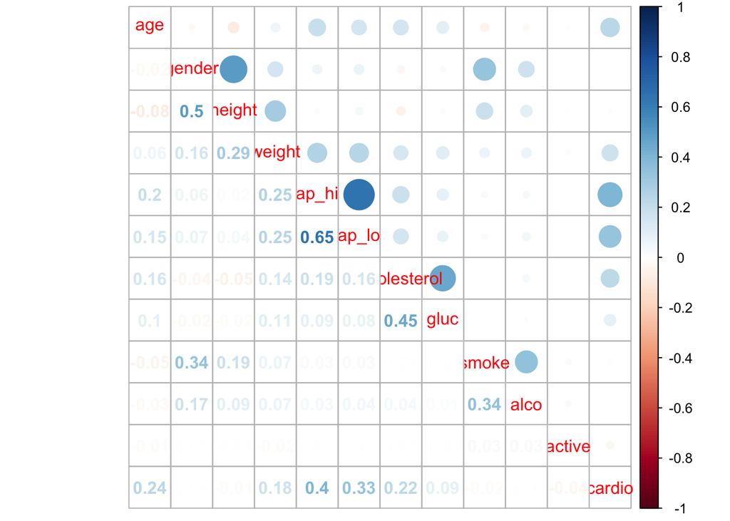

There is correlation between cardio and ap_hi, ap_lo, age, and cholesterol. However, these are not strong correlations.

Gender, cholesterol, gluc, smoke, alco, active, and cardio variables are converted to factors.

```
## 'data.frame':    68986 obs. of  12 variables:
##  $ age        : num  50 55 52 48 48 60 61 62 48 54 ...
##  $ gender     : Factor w/ 2 levels "1","2": 2 1 1 2 1 1 1 2 1 1 ...
##  $ height     : int  168 156 165 169 156 151 157 178 158 164 ...
##  $ weight     : num  62 85 64 82 56 67 93 95 71 68 ...
##  $ ap_hi      : int  110 140 130 150 100 120 130 130 110 110 ...
##  $ ap_lo      : int  80 90 70 100 60 80 80 90 70 60 ...
##  $ cholesterol: Factor w/ 3 levels "1","2","3": 1 3 3 1 1 2 3 3 1 1 ...
##  $ gluc       : Factor w/ 3 levels "1","2","3": 1 1 1 1 1 2 1 3 1 1 ...
##  $ smoke      : Factor w/ 2 levels "0","1": 1 1 1 1 1 1 1 1 1 1 ...
##  $ alco       : Factor w/ 2 levels "0","1": 1 1 1 1 1 1 1 1 1 1 ...
##  $ active     : Factor w/ 2 levels "0","1": 2 2 1 2 1 1 2 2 2 1 ...
##  $ cardio     : Factor w/ 2 levels "0","1": 1 2 2 2 1 1 1 2 1 1 ...
```

## Chapter 3: EDA

Except the response variable cardio, there are 6 categorical variables in our dataset: gender, cholesterol, glucose, smoking, alcohol and physical activity.

We’ll look at barplots and $\chi^{2}$ tests for each of them.

Cardio vs Cholesterol:

Barplot:

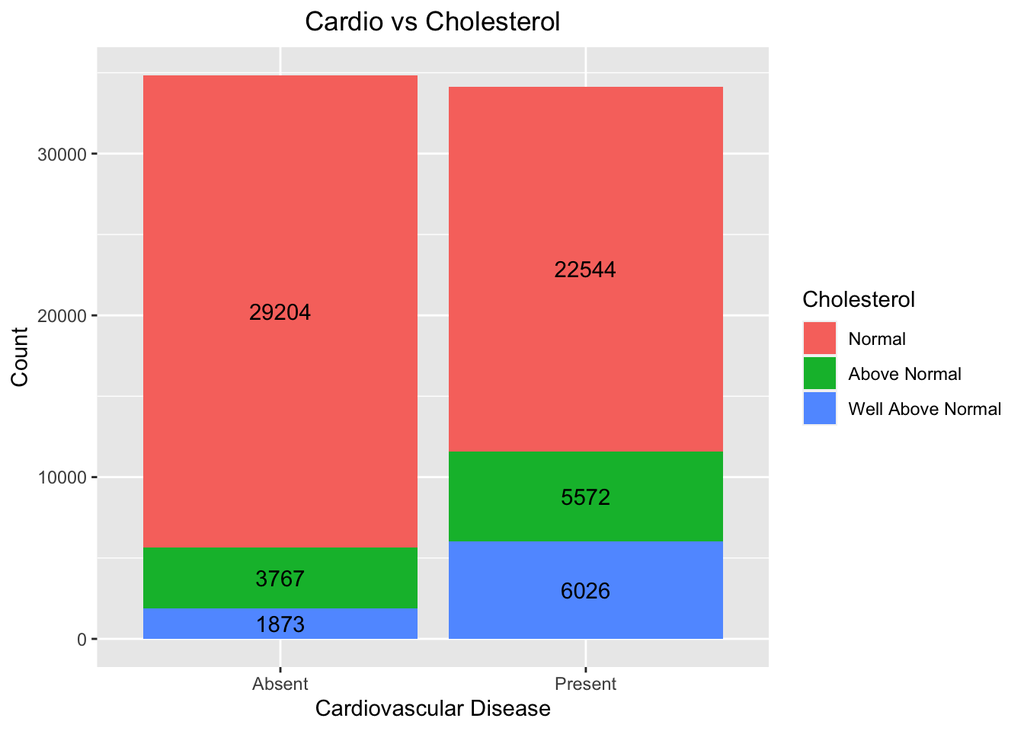

$\chi^{2}$ test of independence:

```
##
##  Pearson's Chi-squared test
##
## data:  cho_cont
## X-squared = 3383, df = 2, p-value <2e-16
```

The p-value is 0. We can reject the null hypothesis because the p-value is much smaller than the alpha value 0.05. The null hypothesis of the test is that these two variables are independent. Hence, the cholesterol levels do have effects on cardiovasuclar disease.

Cardio vs Glucose:

Barplot:

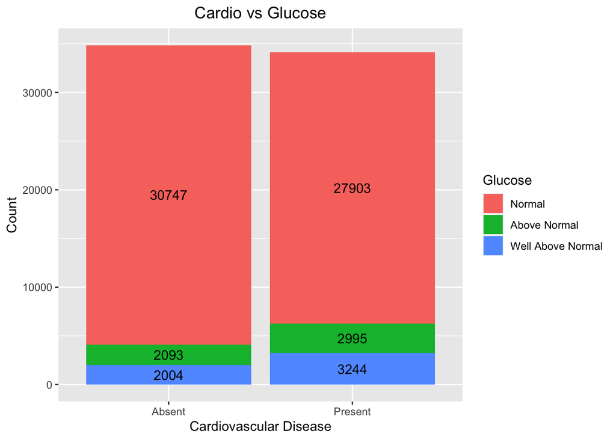

$\chi^{2}$ test of independence:

```
##
##  Pearson's Chi-squared test
##
## data:  gluc_cont
## X-squared = 584, df = 2, p-value <2e-16
```

The p-value is 1.76610^{-127}. We can reject the null hypothesis because the p-value is much smaller than the alpha value 0.05. The null hypothesis of the test is that these two variables are independent. Hence, the glucose levels do have effects on cardiovasuclar disease.

Cardio vs Gender:

Barplot:

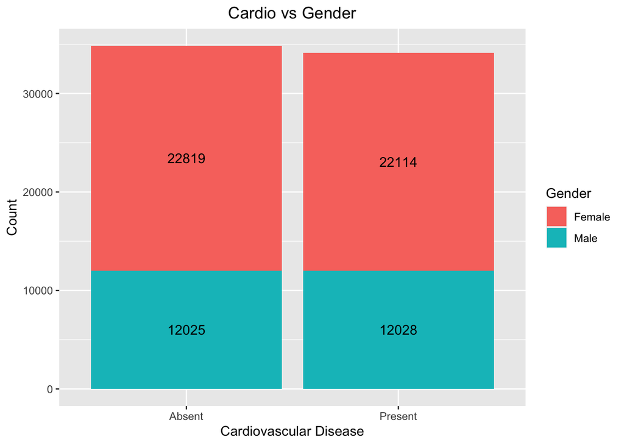

$\chi^{2}$ goodness of fit test:

```
##
##  Chi-squared test for given probabilities
##
## data:  genders
## X-squared = 8, df = 1, p-value = 0.005
```

The p-value is 0.005. We can reject the null hypothesis because the p-value is less than the alpha value 0.05. The null hypothesis of the test is that these two variables are independent. Hence, gender does have effects on cardiovasuclar disease.

Cardio vs Smoking:

Barplot:

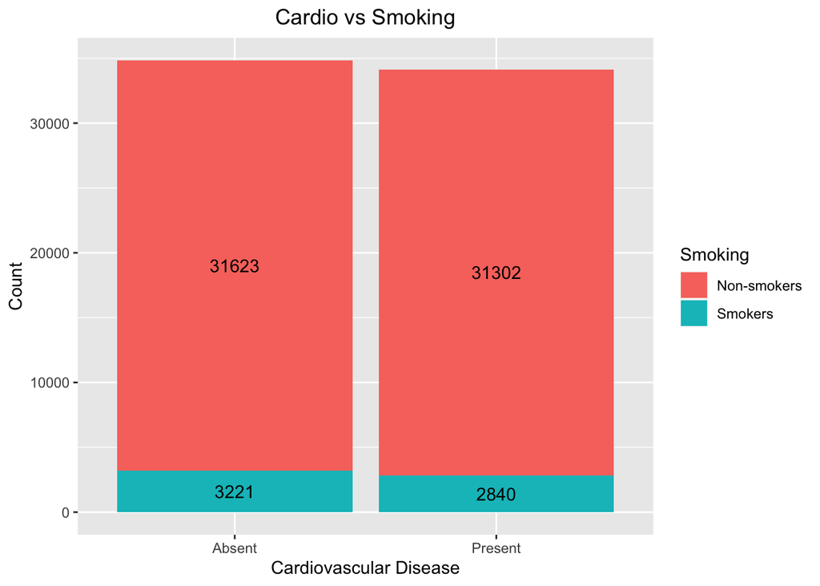

$\chi^{2}$ goodness of fit test:

```
##
##  Chi-squared test for given probabilities
##
## data:  smokes
## X-squared = 35, df = 1, p-value = 3e-09
```

The p-value is 3.49710^{-9}. We can reject the null hypothesis because the p-value is less than the alpha value 0.05. The null hypothesis of the test is that these two variables are independent. Hence, smoke does have effects on cardiovasuclar disease.

Cardio vs Alcohol:

Barplot:

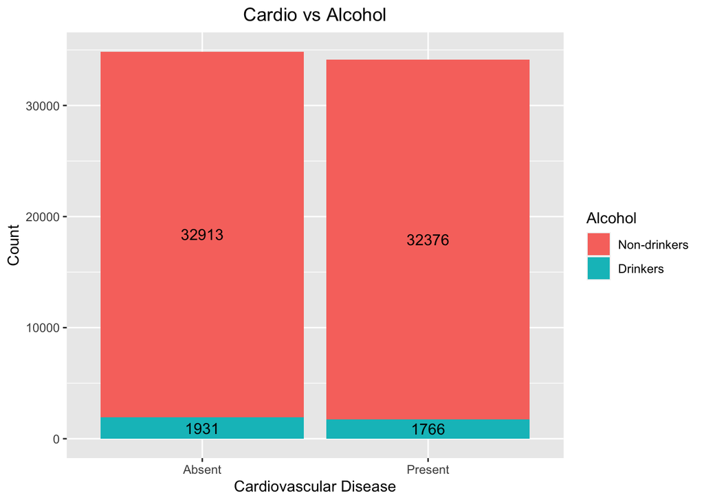

$\chi^{2}$ goodness of fit test:

```
##
##  Chi-squared test for given probabilities
##
## data:  alcos
## X-squared = 9, df = 1, p-value = 0.003
```

The p-value is 0.003. We can reject the null hypothesis because the p-value is less than the alpha value 0.05. The null hypothesis of the test is that these two variables are independent. Hence, alcohol does have effects on cardiovasuclar disease.

Cardio vs Physical Activity:

Barplot:

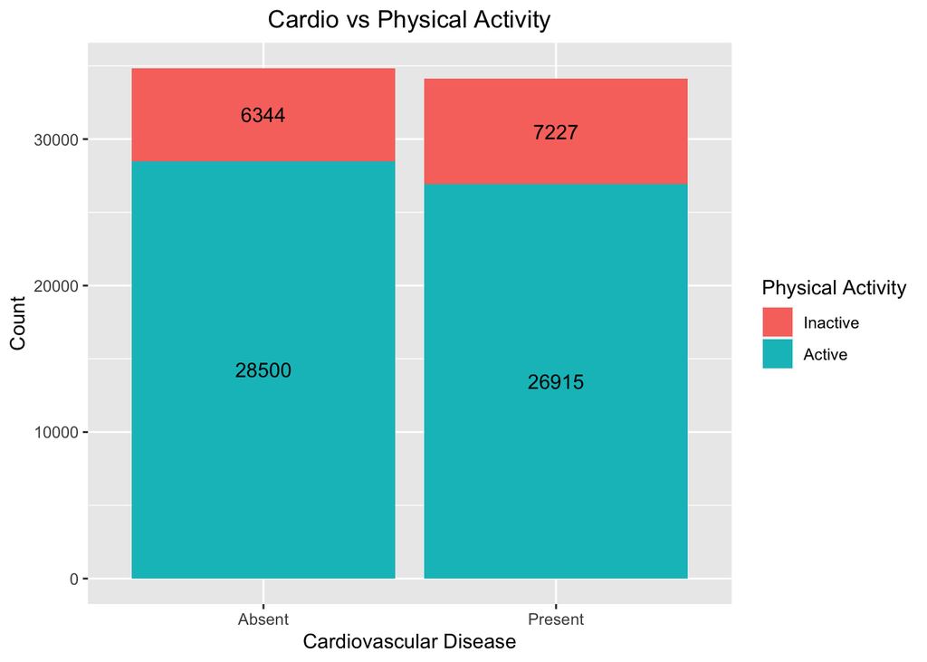

$\chi^{2}$ goodness of fit test:

```
##
##  Chi-squared test for given probabilities
##
## data:  actives
## X-squared = 201, df = 1, p-value <2e-16
```

The p-value is 1.34410^{-45}. We can reject the null hypothesis because the p-value is less than the alpha value 0.05. The null hypothesis of the test is that these two variables are independent. Hence, physical activity does have effects on cardiovasuclar disease.

There are 5 numeric variables: age, height, weight, systolic blood pressure, diastolic blood pressure. Boxplot and Welch’s Two Sample T test (two sided) for each of them.

Cardio vs Age:

Boxplot:

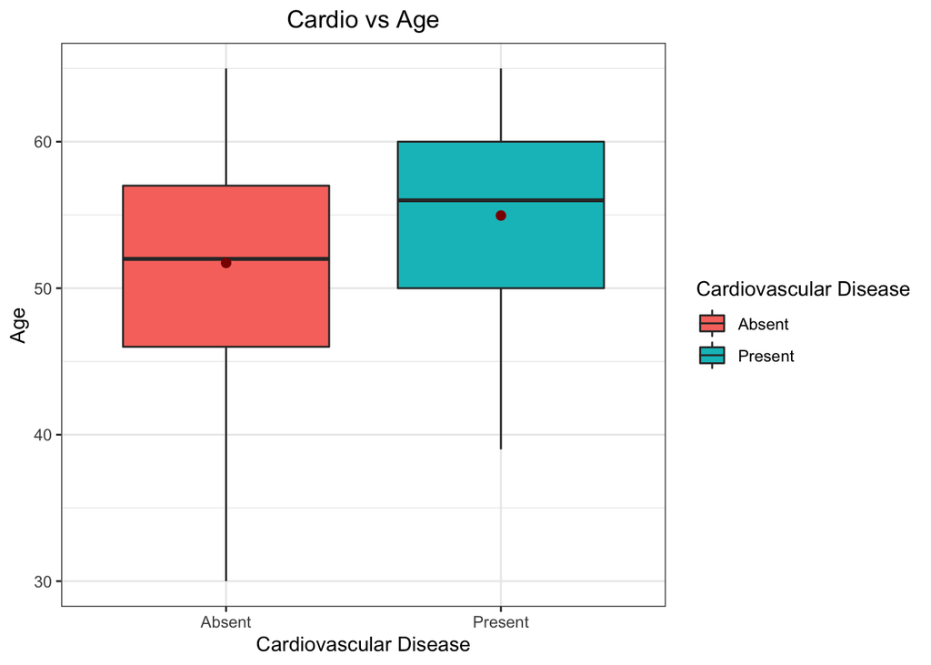

Two Sample T test:

The average age for people who have cardiovascular disease is 54.961.

The average age for people who do not have cardiovascular disease is 51.722.

Let us see if the means are significantly different. We should use a two sample T test to do this.

```
##
##  Welch Two Sample t-test
##
## data:  cardio_present$age and cardio_absent$age
## t = 65, df = 68838, p-value <2e-16
## alternative hypothesis: true difference in means is not equal to 0
## 95 percent confidence interval:
##  3.14 3.34
## sample estimates:
## mean of x mean of y
##      55.0      51.7
```

The p-value of this two sample t-test is 0. It is lower than the alpha value of 0.05, so we can reject the null that the means are equal. Hence, the average age is different for people who have cardiovascular disease and people who do not have cardiovascular disease.

Cardio vs Height:

Boxplot:

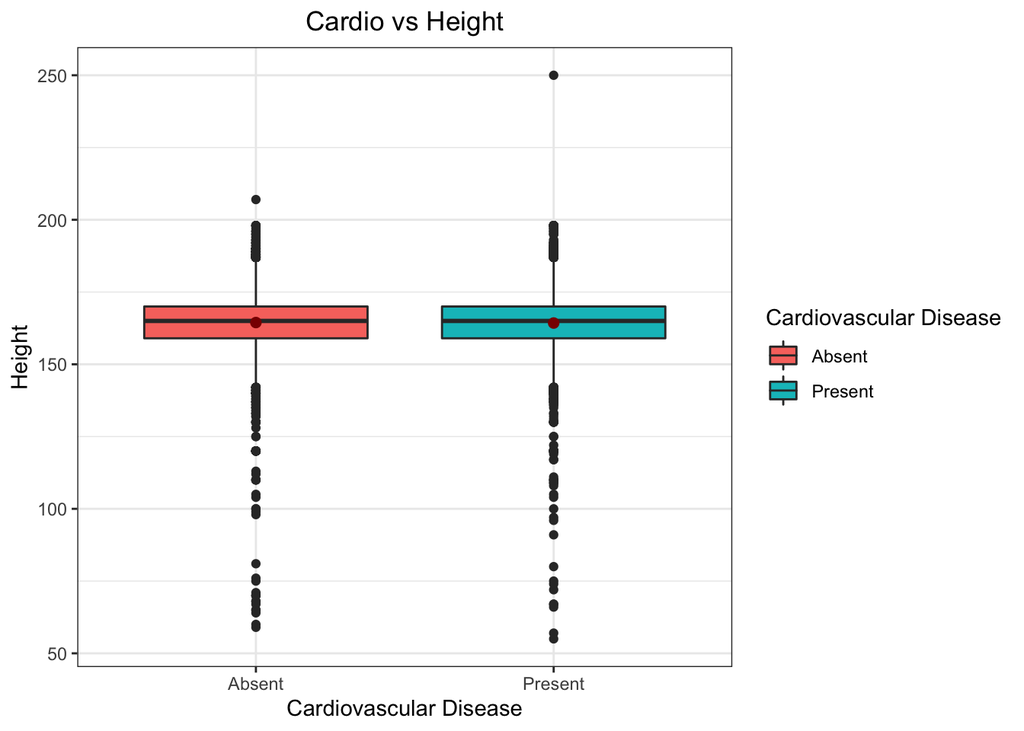

Two Sample T test:

The average height for people who have cardiovascular disease is 164.273.

The average height for people who do not have cardiovascular disease is 164.444.

Let us see if the means are significantly different. We should use a two sample T test to do this.

```
##
##  Welch Two Sample t-test
##
## data:  cardio_present$height and cardio_absent$height
## t = -3, df = 68904, p-value = 0.006
## alternative hypothesis: true difference in means is not equal to 0
## 95 percent confidence interval:
##  -0.294 -0.049
## sample estimates:
## mean of x mean of y
##       164       164
```

The p-value of this two sample t-test is 0.006. It is lower than the alpha value of 0.05, so we can reject the null that the means are equal. Hence, the average height is different for people who have cardiovascular disease and people who do not have cardiovascular disease.

Cardio vs Weight:

Boxplot:

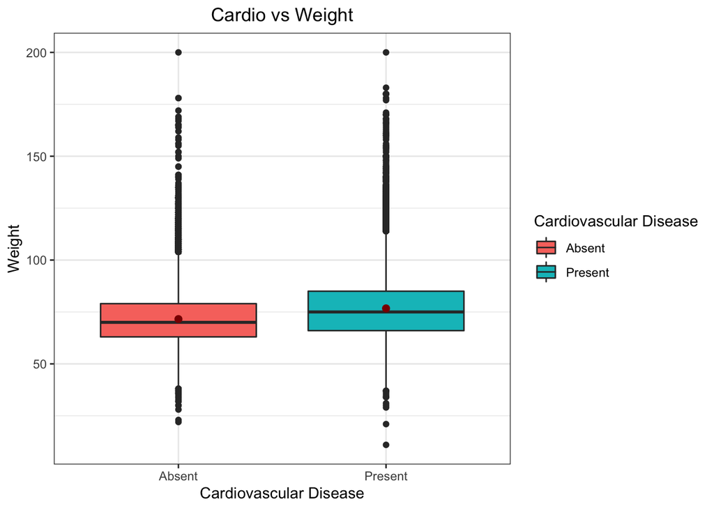

Two Sample T test:

The average weight for people who have cardiovascular disease is 76.724.

The average weight for people who do not have cardiovascular disease is 71.566.

Let us see if the means are significantly different. We should use a two sample T test to do this.

```
##
##  Welch Two Sample t-test
##
## data:  cardio_present$weight and cardio_absent$weight
## t = 48, df = 67789, p-value <2e-16
## alternative hypothesis: true difference in means is not equal to 0
## 95 percent confidence interval:
##  4.95 5.37
## sample estimates:
## mean of x mean of y
##      76.7      71.6
```

The p-value of this two sample t-test is 0. It is lower than the alpha value of 0.05, so we can reject the null that the means are equal. Hence, the average weight is different for people who have cardiovascular disease and people who do not have cardiovascular disease.

Cardio vs Systolic Blood Pressure:

Boxplot:

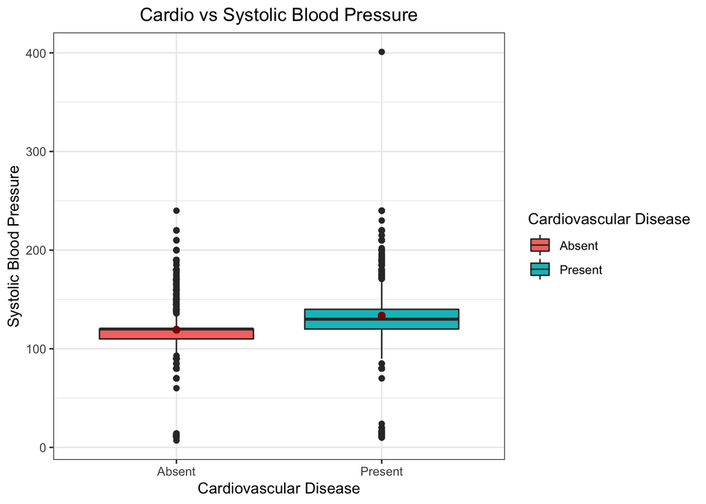

Two Sample T test:

The average systolic blood pressure for people who have cardiovascular disease is 133.511.

The average systolic blood pressure for people who do not have cardiovascular disease is 119.292.

Let us see if the means are significantly different. We should use a two sample T test to do this.

```
##
##  Welch Two Sample t-test
##
## data:  cardio_present$ap_hi and cardio_absent$ap_hi
## t = 115, df = 62999, p-value <2e-16
## alternative hypothesis: true difference in means is not equal to 0
## 95 percent confidence interval:
##  14.0 14.5
## sample estimates:
## mean of x mean of y
##       134       119
```

The p-value of this two sample t-test is 0. It is lower than the alpha value of 0.05, so we can reject the null that the means are equal. Hence, the average systolic blood pressure is different for people who have cardiovascular disease and people who do not have cardiovascular disease.

Cardio vs Diastolic Blood Pressure:

Boxplot:

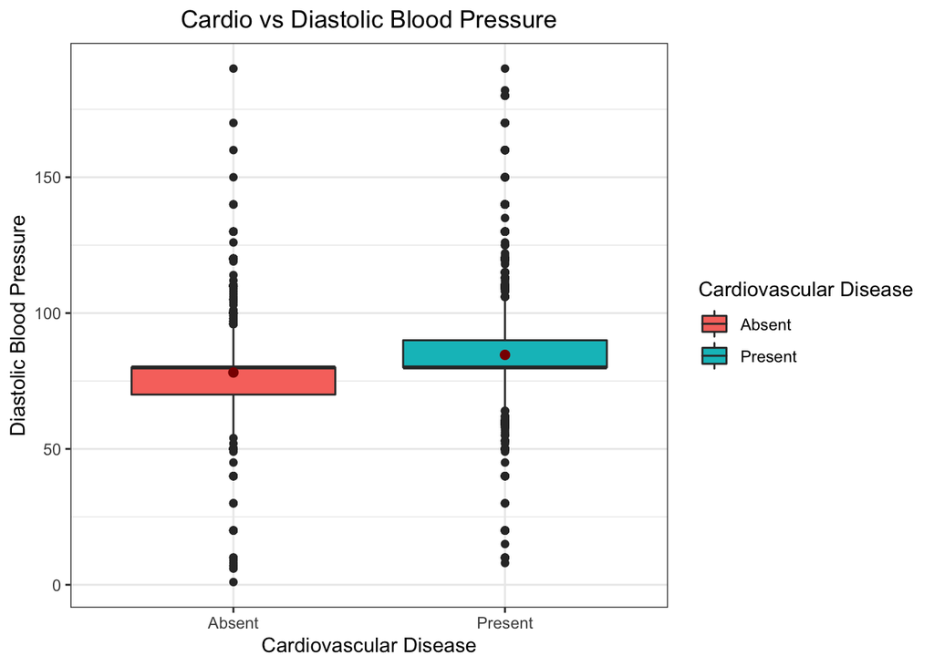

Two Sample T test:

The average diastolic blood pressure for people who have cardiovascular disease is 84.626.

The average diastolic blood pressure for people who do not have cardiovascular disease is 78.141.

Let us see if the means are significantly different. We should use a two sample T test to do this.

```
##
##  Welch Two Sample t-test
##
## data:  cardio_present$ap_lo and cardio_absent$ap_lo
## t = 92, df = 66573, p-value <2e-16
## alternative hypothesis: true difference in means is not equal to 0
## 95 percent confidence interval:
##  6.35 6.62
## sample estimates:
## mean of x mean of y
##      84.6      78.1
```

The p-value of this two sample t-test is 0. It is lower than the alpha value of 0.05, so we can reject the null that the means are equal. Hence, the average diastolic blood pressure is different for people who have cardiovascular disease and people who do not have cardiovascular disease.

## Chapter 4 Decision tree

The dataset is splitted into 70% train set and 30% test set. We use Decision Tree to predict patients with cardiovascular disease. We will construct classification tree because our target variable is categorical.

### 4.1 Classification Tree 1

[figure not shown]

Decision Tree Evaluation

```
## Confusion Matrix and Statistics
##
##           Reference
## Prediction    0    1
##          0 7778 3129
##          1 2624 7165
##
##                Accuracy : 0.722
##                  95% CI : (0.716, 0.728)
##     No Information Rate : 0.503
##     P-Value [Acc > NIR] : < 2e-16
##
##                   Kappa : 0.444
##
##  Mcnemar's Test P-Value : 3.04e-11
##
##             Sensitivity : 0.748
##             Specificity : 0.696
##          Pos Pred Value : 0.713
##          Neg Pred Value : 0.732
##              Prevalence : 0.503
##          Detection Rate : 0.376
##    Detection Prevalence : 0.527
##       Balanced Accuracy : 0.722
##
##        'Positive' Class : 0
##
```

The overall accuracy is 72.2%.

This tree uses the following variables: ap_hi, age, cholesterol, ative, smoke, and weight. The first split is based on ap_hi value 130. If the patient’s systolic pressure is below 130, then we go to the left branch. If ap_hi is higher than 130, we go to the right. There is no more split in the right branch. 76% of patients belong to this right branch are predicted to get cardiovascular disease. The left branch has more splits based on age, cholesterol, active, smoke, and weight. From the tree, we can say that people younger than 55 with normal or just above normal cholesterol levels are less likely to be predicted to have CVD. The tree predicts only 22% of this group having CVD. For people older than 55, it depends on other factors such as their physical activity, smoking habit, and their weight. If they are active, non-smokers, less than 91 kg and less than 63 years of age, the tree predicts 46% of this group are having CVD. It seems like for older people, it does not matter if they exercise, non-smoke, and keep a healthy weight, they still have a 46% prediction of getting the disease. However, the data collected from patients may be subjective because we don’t know how they actually considered active, or smoking habit.

Therefore, another tree is created with less levels below.

### 4.2 Classification Tree 2

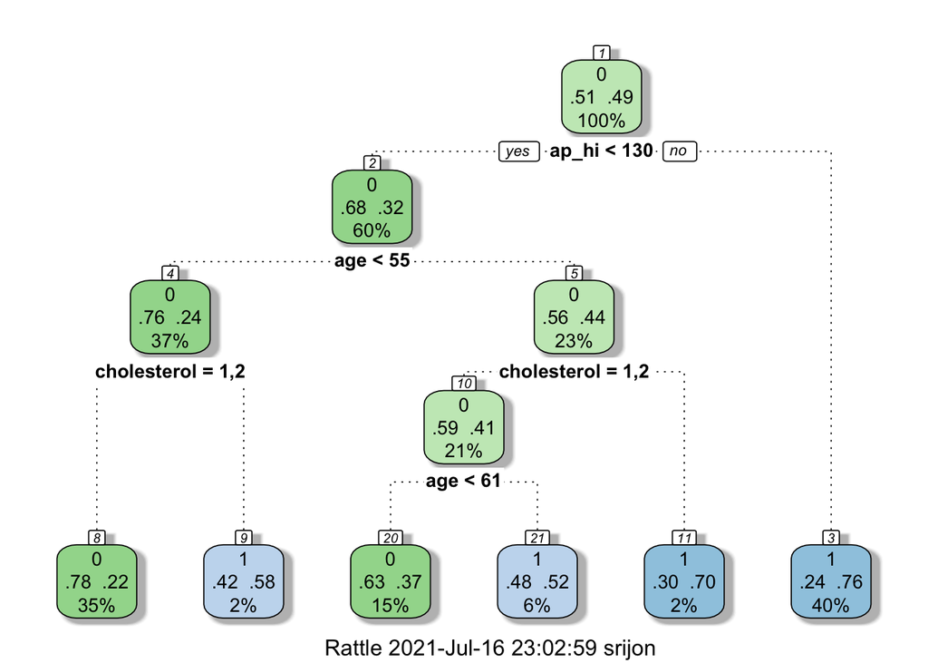

Decision Tree Evaluation

```
## Confusion Matrix and Statistics
##
##           Reference
## Prediction    0    1
##          0 7515 2897
##          1 2887 7397
##
##                Accuracy : 0.721
##                  95% CI : (0.714, 0.727)
##     No Information Rate : 0.503
##     P-Value [Acc > NIR] : <2e-16
##
##                   Kappa : 0.441
##
##  Mcnemar's Test P-Value : 0.906
##
##             Sensitivity : 0.722
##             Specificity : 0.719
##          Pos Pred Value : 0.722
##          Neg Pred Value : 0.719
##              Prevalence : 0.503
##          Detection Rate : 0.363
##    Detection Prevalence : 0.503
##       Balanced Accuracy : 0.721
##
##        'Positive' Class : 0
##
```

Overall Accuracy is 72.1%, not much difference from the first tree. However, this second tree is easier to classify cardiovascular disease. This second tree uses the most important variables that affect the chance of getting the disease such as ap_hi, age, and cholesterol variables. The subjective variables such as smoke or active levels are removed. The other factors even though contribute to the disease, but do not have high importance.

The first split in the tree is still using ap_hi at 130. Only 22% of people with systolic pressure less than 130, younger than 55, and have a normal or above normal cholesterol levels are predicted to have CVD. If they have high cholesterol level, they have 58% chance of getting the disease. If they are over 55 and have high cholesterol level, 70% of this group are predicted to get CVD. On the other hand, if they are over 55 but maintain a normal or above normal chorlesterol level, their chance of getting the disease can be reduced. (37% for people less than 61, and 52% for people older than 61).

## Chapter 5: K-Nearest Neighbors(KNN)

KNN is the second method we used to predict the CVD.Some preprocessing were done, such as scaling the predictors: Age, Height, Weight, Systolic Pressure, Diastolic Pressure. The categorical predictors i.e. Cholesterol and Glucose had three ordinal levels [1: normal, 2: above normal, 3: well above normal]. These two variables were one hot encoded to convert them into dichotomous predictors. The dataset was split into a 7:3 train and test split ratio before building models over the training data points for k-values ranging from 3 to 20.

[output not shown]

[output cut: 647 more lines]

```
##            1 |      3574 |      6720 |     10294 |
##              |     0.347 |     0.653 |     0.497 |
##              |     0.304 |     0.753 |           |
##              |     0.173 |     0.325 |           |
## -------------|-----------|-----------|-----------|
## Column Total |     11775 |      8921 |     20696 |
##              |     0.569 |     0.431 |           |
## -------------|-----------|-----------|-----------|
##
##
## [1] "Accuracy =  0.720960572091225"
## [1] "--------------------------------------------------------"
## [1] "--------------------------------------------------------"
## [1] "                                                        "
## [1] "                                                        "
```

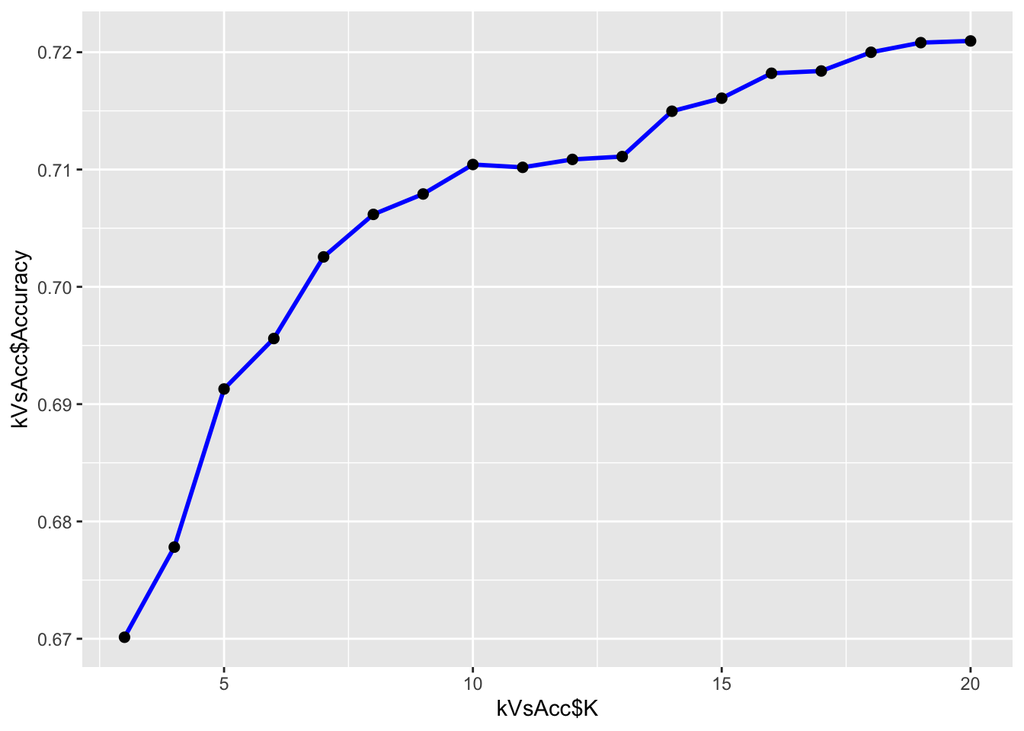

The accuracy of the models when applied over the test data points seems to be improving and increasing but at a decreasing rate. However using the elbow method we observed that right around k=20 and onwards the incremental improvement trails off. The accuracy at this k-value is 72.1% which is the almost same as that of the decision tree model’s accuracy.

## Chapter 6: Logistic Regression

I split the sample in to a training and test set with a 70-30 ratio to run a logistic regression model on.

I’ll print out the summary of the logistic model so we can look at the coefficients.

```
##
## Call:
## glm(formula = cardio ~ ap_hi + ap_lo + age + cholesterol + weight +
##     gluc + active + smoke + height + alco + gender, family = "binomial",
##     data = cardio_log_train)
##
## Deviance Residuals:
##    Min      1Q  Median      3Q     Max
## -3.625  -0.933  -0.344   0.946   3.477
##
## Coefficients:
##               Estimate Std. Error z value Pr(>|z|)
## (Intercept)  -1.07e+01   2.83e-01  -37.68  < 2e-16 ***
## ap_hi         4.72e-02   9.92e-04   47.57  < 2e-16 ***
## ap_lo         2.08e-02   1.56e-03   13.32  < 2e-16 ***
## age           5.16e-02   1.60e-03   32.16  < 2e-16 ***
## cholesterol2  3.69e-01   3.23e-02   11.40  < 2e-16 ***
## cholesterol3  1.11e+00   4.25e-02   26.10  < 2e-16 ***
## weight        1.16e-02   8.16e-04   14.24  < 2e-16 ***
## gluc2         3.13e-02   4.25e-02    0.74  0.46081
## gluc3        -3.51e-01   4.72e-02   -7.44  1.0e-13 ***
## active1      -1.94e-01   2.60e-02   -7.48  7.7e-14 ***
## smoke1       -1.60e-01   4.13e-02   -3.87  0.00011 ***
## height       -3.40e-03   1.53e-03   -2.22  0.02620 *
## alco1        -1.84e-01   5.05e-02   -3.65  0.00026 ***
## gender2      -2.13e-02   2.60e-02   -0.82  0.41316
## ---
## Signif. codes:  0 '***' 0.001 '**' 0.01 '*' 0.05 '.' 0.1 ' ' 1
##
## (Dispersion parameter for binomial family taken to be 1)
##
##     Null deviance: 66939  on 48289  degrees of freedom
## Residual deviance: 54736  on 48276  degrees of freedom
## AIC: 54764
##
## Number of Fisher Scoring iterations: 4
```

All p-values are small, except for gluc2 and gender2. It seems like gender or the glucose levels 1 and 2 don’t have a lot of effect on cardio disease. However, glucose level 3 (the highest level) and other variables do affect cardio disease. I’m also very suspiscious of the negative coefficient that smoking shows. That smoking and cardiovascular disease have a postiive correlation is something that’s common knowledge and not something I’m willing to contest. This could be possible overfitting messing with the coefficient signs. It could also be that a large number of patients who reported to having cardiovascular disease, denied smoking.

I’ll use this model to predict on the training set and generate an ROC curve from which I’ll derive a threshold value to work with.

```
## [1] 0.789
```

Area under the curve is only 0.789. This is not considered a very good model.

```
##
##     FALSE  TRUE
##   0 21165  3226
##   1 10827 13072
```

I’ll run this model on test data next and compute the accuracy.

Accuracy of the model on the test data:

```
## [1] 0.708
```

The accuracy is 70.8%. This is a little less than the KNN and decision tree’s accuracies.

Fitting again, after rearranging some of the parameters and removing gender:

```
##
## Call:
## glm(formula = cardio ~ ap_hi + ap_lo + age + cholesterol + weight +
##     gluc + active + smoke + height + alco, family = "binomial",
##     data = cardio_log_train)
##
## Deviance Residuals:
##    Min      1Q  Median      3Q     Max
## -3.627  -0.932  -0.344   0.946   3.479
##
## Coefficients:
##               Estimate Std. Error z value Pr(>|z|)
## (Intercept)  -1.06e+01   2.60e-01  -40.56  < 2e-16 ***
## ap_hi         4.72e-02   9.91e-04   47.57  < 2e-16 ***
## ap_lo         2.08e-02   1.56e-03   13.31  < 2e-16 ***
## age           5.15e-02   1.60e-03   32.16  < 2e-16 ***
## cholesterol2  3.69e-01   3.23e-02   11.43  < 2e-16 ***
## cholesterol3  1.11e+00   4.25e-02   26.12  < 2e-16 ***
## weight        1.16e-02   8.16e-04   14.24  < 2e-16 ***
## gluc2         3.14e-02   4.25e-02    0.74  0.45929
## gluc3        -3.50e-01   4.72e-02   -7.43  1.1e-13 ***
## active1      -1.94e-01   2.60e-02   -7.48  7.6e-14 ***
## smoke1       -1.68e-01   3.99e-02   -4.22  2.5e-05 ***
## height       -3.95e-03   1.37e-03   -2.88  0.00394 **
## alco1        -1.86e-01   5.04e-02   -3.69  0.00022 ***
## ---
## Signif. codes:  0 '***' 0.001 '**' 0.01 '*' 0.05 '.' 0.1 ' ' 1
##
## (Dispersion parameter for binomial family taken to be 1)
##
##     Null deviance: 66939  on 48289  degrees of freedom
## Residual deviance: 54737  on 48277  degrees of freedom
## AIC: 54763
##
## Number of Fisher Scoring iterations: 4
```

Not much of a change this time. I’ll still continue.

Making the predictions on the training data and looking at the ROC curve:

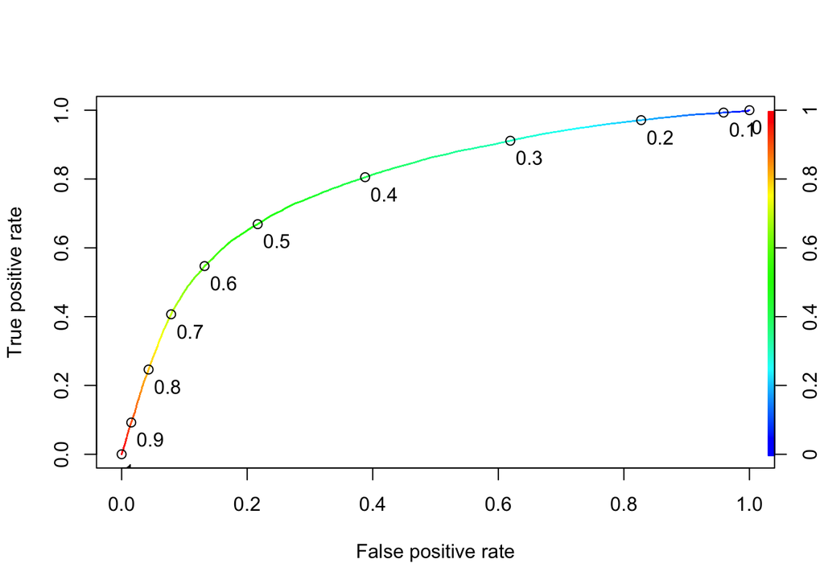

Let’s see the accuracy for this model.

```
## [1] 0.789
```

Area under the curve is still 0.789. It doesn’t inmprove from the first logistic model.

Running on the test set again:

Confusion matrix for the test:

```
##
##     FALSE TRUE
##   0  9080 1373
##   1  4656 5587
```

Accuracy of the second model:

```
## [1] 0.709
```

I’m not happy with this as there is high multicollinearity. We’re gonna try a model with principal components now.

## Chapter 7: PCR Analysis

I wanted to do a PCR to see if a dimensional analysis would help with the overfitting.

Building the components and looking at the distribution of variance:

The most important component has 20% of the variance, the second component has 15.9% of variance, and the third component has 10.8% variance.

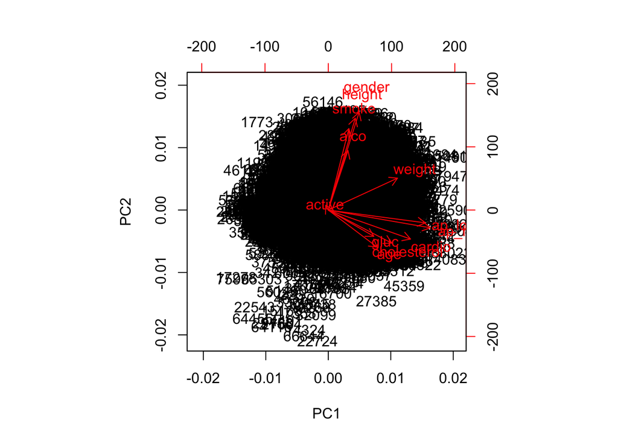

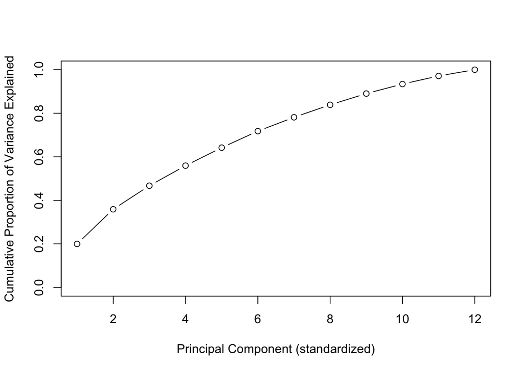

Each component has a certain percentage in variance. It takes 10 components to capture 90% of variance. Turns out there’s a lot of variance and I’m not being able to reduce much of the components.

We build the data frame with the components and split the data into training and test sets 7:3 ratio.

Fitting a glm on the pcr training set and looking at the coefficients:

```
##
## Call:
## glm(formula = cardio ~ . - PC11, family = "binomial", data = cardio_pcr_train)
##
## Deviance Residuals:
##    Min      1Q  Median      3Q     Max
## -3.854  -0.934  -0.341   0.946   3.517
##
## Coefficients:
##              Estimate Std. Error z value Pr(>|z|)
## (Intercept) -1.09e+01   2.76e-01  -39.66  < 2e-16 ***
## PC1          5.82e-02   6.97e-04   83.46  < 2e-16 ***
## PC2          1.21e-02   7.96e-04   15.19  < 2e-16 ***
## PC3          2.35e-02   1.37e-03   17.16  < 2e-16 ***
## PC4         -4.56e-03   1.68e-03   -2.71   0.0067 **
## PC5          4.99e-02   1.61e-03   30.97  < 2e-16 ***
## PC6          3.39e-01   1.43e-02   23.60  < 2e-16 ***
## PC7         -3.48e-01   2.37e-02  -14.65  < 2e-16 ***
## PC8          1.24e-01   2.41e-02    5.12  3.0e-07 ***
## PC9         -2.07e-01   2.60e-02   -7.98  1.5e-15 ***
## PC10         1.98e-01   3.81e-02    5.20  2.0e-07 ***
## ---
## Signif. codes:  0 '***' 0.001 '**' 0.01 '*' 0.05 '.' 0.1 ' ' 1
##
## (Dispersion parameter for binomial family taken to be 1)
##
##     Null deviance: 66939  on 48289  degrees of freedom
## Residual deviance: 54793  on 48279  degrees of freedom
## AIC: 54815
##
## Number of Fisher Scoring iterations: 4
```

Predicting on the training set and looking at the ROC curve to decide a threshold:

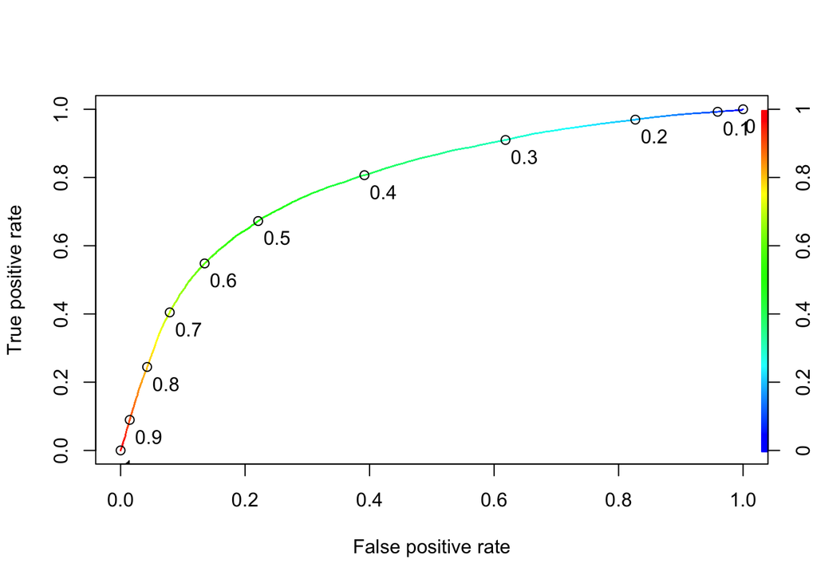

The AUC is still 0.788, though. No change.

I’ll run this on the test set.

Table for predictions on test data:

```
##
##     FALSE TRUE
##   0  9082 1371
##   1  4676 5567
```

Accuracy for fit on test data:

```
## [1] 0.708
```

Fit after removing Principal Component 4:

```
##
## Call:
## glm(formula = cardio ~ . - PC4 - PC11, family = "binomial", data = cardio_pcr_train)
##
## Deviance Residuals:
##    Min      1Q  Median      3Q     Max
## -3.861  -0.933  -0.343   0.946   3.553
##
## Coefficients:
##              Estimate Std. Error z value Pr(>|z|)
## (Intercept) -1.09e+01   2.74e-01  -39.66  < 2e-16 ***
## PC1          5.83e-02   6.96e-04   83.79  < 2e-16 ***
## PC2          1.22e-02   7.95e-04   15.40  < 2e-16 ***
## PC3          2.34e-02   1.37e-03   17.12  < 2e-16 ***
## PC5          4.98e-02   1.61e-03   30.91  < 2e-16 ***
## PC6          3.38e-01   1.43e-02   23.57  < 2e-16 ***
## PC7         -3.47e-01   2.37e-02  -14.63  < 2e-16 ***
## PC8          1.24e-01   2.41e-02    5.13  2.9e-07 ***
## PC9         -2.07e-01   2.60e-02   -7.96  1.7e-15 ***
## PC10         1.98e-01   3.81e-02    5.19  2.1e-07 ***
## ---
## Signif. codes:  0 '***' 0.001 '**' 0.01 '*' 0.05 '.' 0.1 ' ' 1
##
## (Dispersion parameter for binomial family taken to be 1)
##
##     Null deviance: 66939  on 48289  degrees of freedom
## Residual deviance: 54800  on 48280  degrees of freedom
## AIC: 54820
##
## Number of Fisher Scoring iterations: 4
```

Using glm model on training data and generating a ROC curve:

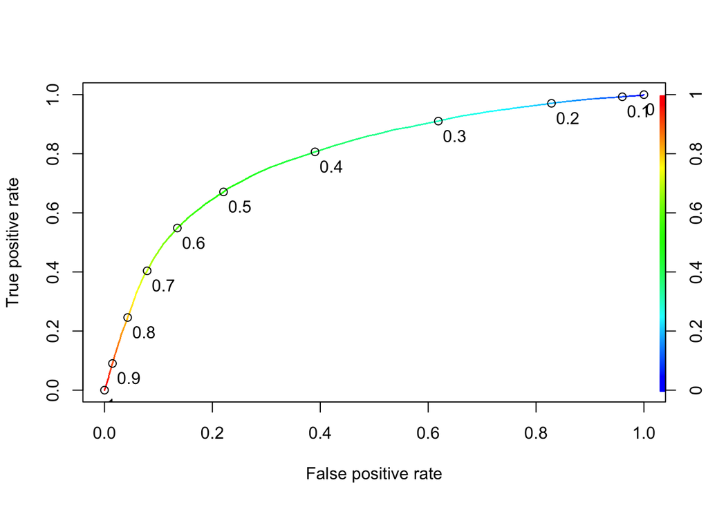

Running model on test data:

Accuracy for second fit on the test data:

```
## [1] 0.708
```

So it seems the second fit still had no effect on my AUC and accuracy. PCR didn’t change much of my results.

## Chapter 8: Conclusion

We choose KNN and Decision Tree as our best models to predict cardiovascular disease. However, in reality, 72.2% accuracy is low and may not be accepted to use in health care system. On the other side, some of the variables were answered by patient’s subjective opinion. Each patient may have a different opinions for being active, smoking, and alcohol intake, so some data we have might be bias. It would be better if we can have unbiased information by asking a frequency question like how many times a patient exercise per week and how long is one session. Same type of questions can be asked for alcohol intake and smoking.

In conclusion, after analyzing this dataset and performing different models, we conclude that KNN and Decision Tree are the best models from our results. Blood pressure, age, and cholesterol are the important factors contribute to cardiovascular disease. However, keeping the healthy lifestyle will affect the chance of getting cardiovascular disease. Drinking, smoking, and daily diet affect blood pressure and cholesterol and therefore they will indirectly affect the heart functions. A few take home keypoints are exercise regularly, do not smoke or drink alcohol.

## Chapter 9: References

https://www.who.int

https://www.cdc.gov/heartdisease/facts.html

https://www.kaggle.com/sulianova/cardiovascular-disease-dataset